# ST758 2014 HW1

Hua Zhou

Sep 1st, 2014

# Q1

Why not test equality with floating point numbers

```r
seven <- .7
two <- .2
one <- .1
```

Surprised?

```r
1 == (seven + two) + one
```

```
## [1] FALSE
```

```r
1 == seven + (two + one)
```

```
## [1] TRUE
```

```r
1 == (seven + one) + two
```

```
## [1] TRUE
```

Now let’s look at the internal representation:

```r
sprintf("%a", c(seven, two, one))       # three numbers
```

```
## [1] "0x1.6666666666666p-1" "0x1.999999999999ap-3" "0x1.999999999999ap-4"
```

- Binary format of 0.7 is $1.0110...0110 \times 2^{-1}$
- Binary format of 0.2 is $1.1001...1010 \times 2^{-3}$ (rounding happens here)
- Binary format of 0.1 is $1.1001...1010 \times 2^{-4}$ (rounding happens here)  
  Let’s take a look at the intemediate numbers when doing (0.7 + 0.2) + 0.1.

```r
sprintf("%a", c(seven + two, one))
```

```
## [1] "0x1.cccccccccccccp-1" "0x1.999999999999ap-4"
```

```r
sprintf("%a", (seven + two) + one)
```

```
## [1] "0x1.fffffffffffffp-1"
```

For the partial sum 0.7 + 0.2, computer (1) aligns the exponent, (2) performs addition, and then (3) normalizes the result. So we get $\begin{eqnarray*} 1.0110...0110 &\times& 2^{-1} \\ + 0.0110...0110 &\times& 2^{-1} \\ = 1.1100...1100 &\times& 2^{-1} \end{eqnarray*}$ Note in the aligning exponent step, we lost the last two digis of 0.2. Next we add the partial sum to 0.1 $\begin{eqnarray*} 1.1100...1100 &\times& 2^{-1} \\ + 0.0011...0011 &\times& 2^{-1} \\ = 1.1111...1111 &\times& 2^{-1} \end{eqnarray*}$ Note again we lost three digits from 0.1 when aligning exponents. The final result is a bit off from 1.

```r
sprintf("%a", 1)
```

```
## [1] "0x1p+0"
```

You may work on the other two orders: 0.7 + (0.2 + 0.1) and (0.7 + 0.1) + 0.2, which lead to exact 1.

```r
sprintf("%a", c(seven, two + one))      # partial sum
```

```
## [1] "0x1.6666666666666p-1" "0x1.3333333333334p-2"
```

```r
sprintf("%a", seven + (two + one))        # why it's not one
```

```
## [1] "0x1p+0"
```

(0.7+0.1)+0.2

```r
sprintf("%a", c(seven + one, two))      # partial sum
```

```
## [1] "0x1.9999999999999p-1" "0x1.999999999999ap-3"
```

```r
sprintf("%a", (seven + one) + two)        # why it's not one
```

```
## [1] "0x1p+0"
```

# Q2

```r
allbut970 <- c(969, 971:1023)
length(allbut970)
```

```
## [1] 54
```

```r
sum(2^allbut970)
```

```
## [1] Inf
```

Reference – this should be biggest number

```r
biggest <- .Machine$double.xmax
biggest
```

```
## [1] 1.798e+308
```

```r
sprintf("%a", biggest)
```

```
## [1] "0x1.fffffffffffffp+1023"
```

Adding two numbers of dramatically different magnitudes, we get a+b=a! Catastropic cancellation 1.

```r
sum(2^allbut970[-1])
```

```
## [1] 1.798e+308
```

```r
2^allbut970[1] + sum(2^allbut970[-1])
```

```
## [1] 1.798e+308
```

Ok, that’s weird enough, what are they internally?

```r
sprintf("%a", sum(2^allbut970[-1]))
```

```
## [1] "0x1.fffffffffffffp+1023"
```

```r
sprintf("%a", sum(2^allbut970[-1]) + 2^allbut970[1])
```

```
## [1] "0x1.fffffffffffffp+1023"
```

Now look at internal view of cumulative sums

```r
c1 <- sprintf("%a", cumsum(2^allbut970[1:53]))
c2 <- sprintf("%a", cumsum(2^allbut970[2:54]))
cbind(c1, c2)
```

```
##       c1                        c2
##  [1,] "0x1p+969"                "0x1p+971"
##  [2,] "0x1.4p+971"              "0x1.8p+972"
##  [3,] "0x1.ap+972"              "0x1.cp+973"
##  [4,] "0x1.dp+973"              "0x1.ep+974"
##  [5,] "0x1.e8p+974"             "0x1.fp+975"
##  [6,] "0x1.f4p+975"             "0x1.f8p+976"
##  [7,] "0x1.fap+976"             "0x1.fcp+977"
##  [8,] "0x1.fdp+977"             "0x1.fep+978"
##  [9,] "0x1.fe8p+978"            "0x1.ffp+979"
## [10,] "0x1.ff4p+979"            "0x1.ff8p+980"
## [11,] "0x1.ffap+980"            "0x1.ffcp+981"
## [12,] "0x1.ffdp+981"            "0x1.ffep+982"
## [13,] "0x1.ffe8p+982"           "0x1.fffp+983"
## [14,] "0x1.fff4p+983"           "0x1.fff8p+984"
```

[output cut: 39 more lines]

# Q3

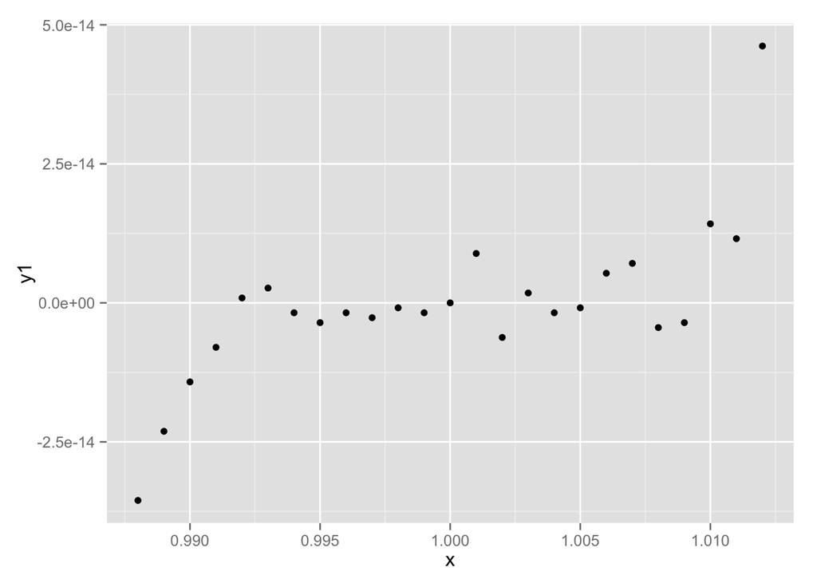

```r
# ggplot2 for nicer graphics
library(ggplot2)
x = seq(from=0.988, to=1.012, by=0.001)
y1 = x^7 - 7 * x^6 + 21 * x^5 - 35 * x^4 + 35 * x^3 - 21 * x^2 + 7 * x - 1
qplot(x, y1)
```

This avoids catastropic cancellation and the result looks much nicer.

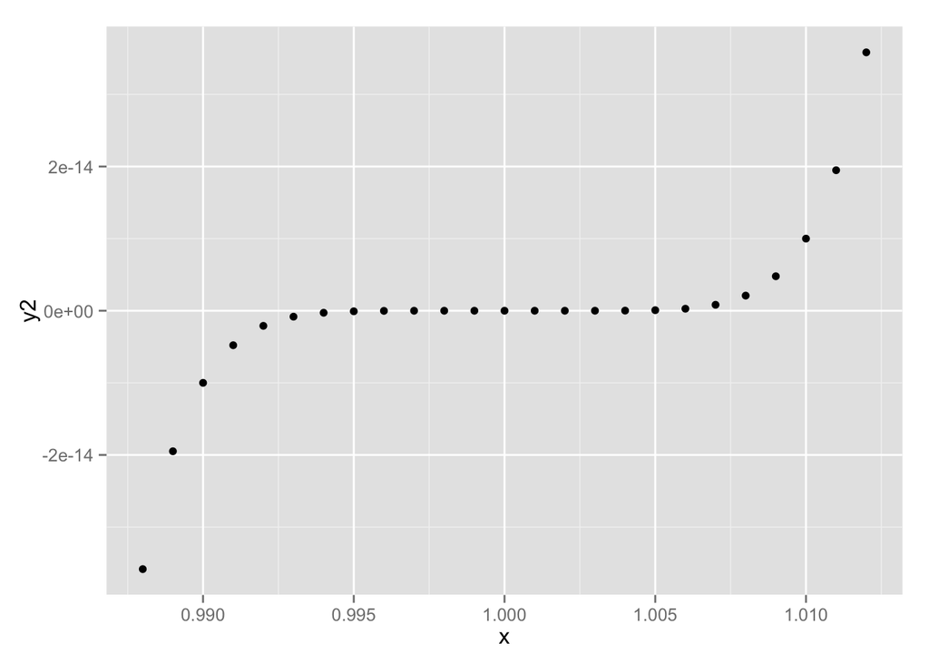

```r
y2 = (x - 1)^7
qplot(x, y2)
```